# Lead Score Case Study

**Names:** Vikas kasina & Jallepalli Prerna

**Time:** 23:30:00

### Other related Instructions

-- All files are extracted from the same folder. There is description of each step written after every code cell.

-- There is mainly **1 Main DataFrames** for which is obtained after cleaning the data and which is used for data modelling named **leadscr_data**

-- Questions of this case study are answered in this notebook.

### Importing the libraries

All the necessary libraries are imported, each library has a following commented line stating the using of the library in this assignment

```python
import pandas as pd
# Pandas library helps in extracting the data from csv or excel files
# into the dataframe and then further manipulating the data according to the necessary format

import numpy as np
# Numpy library helps in statistical calculation and also ploting the best fit line for each state in the assignment

import seaborn as sns
# Seaborn is another visualization library which can be used to plot various charts like, Bar Chart, Pie Chart etc.

import math
# Math library is used to do some basic mathematical operations like square roots etc.

import matplotlib.pyplot as plt
# Matplotlib is a visualization library which can be used to plot various charts like, Bar Chart, Pie Chart etc.

pd.set_option('display.max_columns', None)
pd.set_option('display.max_rows', None)

%matplotlib inline
# The above command is a magical command for ploting graphs in jupyter notebook

import warnings
warnings.filterwarnings("ignore")
# To supress warnings of GLM model
```

## Data Extraction

1 Main Dataframe Any further manipulation will be done using this data frame.

```python
# Importing all datasets
leadscr_data = pd.read_csv("Leads.csv")
```

#### Information of dataset

```python
print(leadscr_data.shape)
print(leadscr_data.info())
```

```
(9240, 37)
<class 'pandas.core.frame.DataFrame'>
RangeIndex: 9240 entries, 0 to 9239
Data columns (total 37 columns):
Prospect ID                                      9240 non-null object
Lead Number                                      9240 non-null int64
Lead Origin                                      9240 non-null object
Lead Source                                      9204 non-null object
Do Not Email                                     9240 non-null object
Do Not Call                                      9240 non-null object
Converted                                        9240 non-null int64
TotalVisits                                      9103 non-null float64
Total Time Spent on Website                      9240 non-null int64
Page Views Per Visit                             9103 non-null float64
Last Activity                                    9137 non-null object
Country                                          6779 non-null object
Specialization                                   7802 non-null object
How did you hear about X Education               7033 non-null object
What is your current occupation                  6550 non-null object
What matters most to you in choosing a course    6531 non-null object
Search                                           9240 non-null object
Magazine                                         9240 non-null object
Newspaper Article                                9240 non-null object
X Education Forums                               9240 non-null object
Newspaper                                        9240 non-null object
Digital Advertisement                            9240 non-null object
Through Recommendations                          9240 non-null object
Receive More Updates About Our Courses           9240 non-null object
Tags                                             5887 non-null object
Lead Quality                                     4473 non-null object
Update me on Supply Chain Content                9240 non-null object
Get updates on DM Content                        9240 non-null object
Lead Profile                                     6531 non-null object
City                                             7820 non-null object
Asymmetrique Activity Index                      5022 non-null object
Asymmetrique Profile Index                       5022 non-null object
Asymmetrique Activity Score                      5022 non-null float64
Asymmetrique Profile Score                       5022 non-null float64
I agree to pay the amount through cheque         9240 non-null object
A free copy of Mastering The Interview           9240 non-null object
Last Notable Activity                            9240 non-null object
dtypes: float64(4), int64(3), object(30)
memory usage: 2.6+ MB
None
```

# import pandas_profiling #Importing the pandas profiling for performing the basic EDA of the data report = pandas_profiling.ProfileReport(leadscr_data) #Store the report into the variable report report.to_file("Quick_EDA.html")

## Data Preperation

#### Converting all the binary categories to 0/1 (Label Encodig)

```python
# Converting Yes to 1 and No to 0
leadscr_data['Do Not Email'] = leadscr_data['Do Not Email'].map({'Yes': 1, 'No': 0})
leadscr_data['Do Not Call'] = leadscr_data['Do Not Call'].map({'Yes': 1, 'No': 0})
leadscr_data['Search'] = leadscr_data['Search'].map({'Yes': 1, 'No': 0})
leadscr_data['Magazine'] = leadscr_data['Magazine'].map({'Yes': 1, 'No': 0})
leadscr_data['Newspaper Article'] = leadscr_data['Newspaper Article'].map({'Yes': 1, 'No': 0})
leadscr_data['X Education Forums'] = leadscr_data['X Education Forums'].map({'Yes': 1, 'No': 0})
leadscr_data['Newspaper'] = leadscr_data['Newspaper'].map({'Yes': 1, 'No': 0})
leadscr_data['Digital Advertisement'] = leadscr_data['Digital Advertisement'].map({'Yes': 1, 'No': 0})
leadscr_data['Through Recommendations'] = leadscr_data['Through Recommendations'].map({'Yes': 1, 'No': 0})
leadscr_data['Receive More Updates About Our Courses'] = leadscr_data['Receive More Updates About Our Courses'].map({'Yes': 1, 'No': 0})
leadscr_data['Update me on Supply Chain Content'] = leadscr_data['Update me on Supply Chain Content'].map({'Yes': 1, 'No': 0})
leadscr_data['Get updates on DM Content'] = leadscr_data['Get updates on DM Content'].map({'Yes': 1, 'No': 0})
leadscr_data['I agree to pay the amount through cheque'] = leadscr_data['I agree to pay the amount through cheque'].map({'Yes': 1, 'No': 0})
leadscr_data['A free copy of Mastering The Interview'] = leadscr_data['A free copy of Mastering The Interview'].map({'Yes': 1, 'No': 0})
```

### Treatment of Null Values and Unnecessary columns

```python
# Calculating the percentage of Null values in each column
total = pd.DataFrame(leadscr_data.isnull().sum().sort_values(ascending=False), columns=['Total'])
percentage = pd.DataFrame(round(100*(leadscr_data.isnull().sum()/leadscr_data.shape[0]),2).sort_values(ascending=False),columns=['Percentage'])
pd.concat([total, percentage], axis = 1)
```

|  | Total | Percentage |
| --- | --- | --- |
| Lead Quality | 4767 | 51.59 |
| Asymmetrique Profile Score | 4218 | 45.65 |
| Asymmetrique Activity Score | 4218 | 45.65 |
| Asymmetrique Profile Index | 4218 | 45.65 |
| Asymmetrique Activity Index | 4218 | 45.65 |
| Tags | 3353 | 36.29 |
| What matters most to you in choosing a course | 2709 | 29.32 |
| Lead Profile | 2709 | 29.32 |
| What is your current occupation | 2690 | 29.11 |
| Country | 2461 | 26.63 |
| How did you hear about X Education | 2207 | 23.89 |
| Specialization | 1438 | 15.56 |
| City | 1420 | 15.37 |
| TotalVisits | 137 | 1.48 |
| Page Views Per Visit | 137 | 1.48 |
| Last Activity | 103 | 1.11 |
| Lead Source | 36 | 0.39 |
| Do Not Email | 0 | 0.00 |
| Do Not Call | 0 | 0.00 |
| Converted | 0 | 0.00 |
| Total Time Spent on Website | 0 | 0.00 |
| Lead Origin | 0 | 0.00 |
| Lead Number | 0 | 0.00 |
| Last Notable Activity | 0 | 0.00 |
| Newspaper Article | 0 | 0.00 |
| Search | 0 | 0.00 |
| Magazine | 0 | 0.00 |
| A free copy of Mastering The Interview | 0 | 0.00 |
| X Education Forums | 0 | 0.00 |
| Newspaper | 0 | 0.00 |
| Digital Advertisement | 0 | 0.00 |
| Through Recommendations | 0 | 0.00 |
| Receive More Updates About Our Courses | 0 | 0.00 |
| Update me on Supply Chain Content | 0 | 0.00 |
| Get updates on DM Content | 0 | 0.00 |
| I agree to pay the amount through cheque | 0 | 0.00 |
| Prospect ID | 0 | 0.00 |

```python
# Removing ID columns
leadscr_data = leadscr_data.drop(['Prospect ID','Lead Number'], axis=1)

# Dropping columns with values same in all rows - useless feature for prediction ; 0 variance
leadscr_data= leadscr_data.loc[:,leadscr_data.nunique()!=1]

# Removing columns with high biased values
leadscr_data = leadscr_data.drop(['Do Not Call','Search','Newspaper Article','Newspaper','Through Recommendations','What matters most to you in choosing a course','How did you hear about X Education'], axis=1)

# Dropping the columns 'Asymmetrique Activity Score' & 'Asymmetrique Profile Score' as they are same as their index columns
leadscr_data = leadscr_data.drop(['Asymmetrique Activity Score','Asymmetrique Profile Score'], axis=1)
```

```python
## Nul Value Imputation
# Continuous with median
leadscr_data['TotalVisits'].replace(np.NaN, leadscr_data['TotalVisits'].median(), inplace =True)
leadscr_data['Page Views Per Visit'].replace(np.NaN, leadscr_data['Page Views Per Visit'].median(), inplace =True)

# Categorical with mode
leadscr_data.loc[pd.isnull(leadscr_data['Country']), ['Country']] = leadscr_data['Country'].mode()[0]

# Treating highly biased column country
leadscr_data['Country'] = leadscr_data['Country'].apply(lambda x: 'India' if x=='India' else 'Abroad')
print(leadscr_data['Country'].value_counts())
print()
# Lead quality column has more null values and cannot be dropped for its importance
print(leadscr_data['Lead Quality'].value_counts())
print()
print(leadscr_data['Lead Quality'].isnull().sum())

# Instead of removong data we can fill it with Unknown response as the selection was not mandatory from the website the data was scraped from
leadscr_data['Lead Quality'].fillna("Unknown", inplace = True)
print(leadscr_data['Lead Quality'].value_counts())
```

```
India     8953
Abroad     287
Name: Country, dtype: int64

Might be             1560
Not Sure             1092
High in Relevance     637
Worst                 601
Low in Relevance      583
Name: Lead Quality, dtype: int64

4767
Unknown              4767
Might be             1560
Not Sure             1092
High in Relevance     637
Worst                 601
Low in Relevance      583
Name: Lead Quality, dtype: int64
```

```python
print(leadscr_data['Asymmetrique Profile Index'].value_counts())
print()
print(leadscr_data['Asymmetrique Activity Index'].value_counts())
print()
print(leadscr_data['Asymmetrique Profile Index'].isnull().sum())
print()
print(leadscr_data['Asymmetrique Activity Index'].isnull().sum())
print()
print(leadscr_data['Asymmetrique Profile Index'].fillna("Unknown", inplace = True))
print()
print(leadscr_data['Asymmetrique Activity Index'].fillna("Unknown", inplace = True))
print()
print(leadscr_data['Asymmetrique Profile Index'].value_counts())
print()
print(leadscr_data['Asymmetrique Activity Index'].value_counts())
```

```
02.Medium    2788
01.High      2203
03.Low         31
Name: Asymmetrique Profile Index, dtype: int64

02.Medium    3839
01.High       821
03.Low        362
Name: Asymmetrique Activity Index, dtype: int64

4218

4218

None

None

Unknown      4218
02.Medium    2788
01.High      2203
03.Low         31
Name: Asymmetrique Profile Index, dtype: int64

Unknown      4218
02.Medium    3839
01.High       821
03.Low        362
Name: Asymmetrique Activity Index, dtype: int64
```

```python
# Doing the same with 'City' column
print(leadscr_data['City'].value_counts())
print()
print(leadscr_data['City'].isnull().sum())
print()
leadscr_data['City'].fillna("Unknown", inplace = True)
leadscr_data['City'].replace('Select', 'Unknown', inplace =True)
print(leadscr_data['City'].value_counts())
print()
```

```
Mumbai                         3222
Select                         2249
Thane & Outskirts               752
Other Cities                    686
Other Cities of Maharashtra     457
Other Metro Cities              380
Tier II Cities                   74
Name: City, dtype: int64

1420

Unknown                        3669
Mumbai                         3222
Thane & Outskirts               752
Other Cities                    686
Other Cities of Maharashtra     457
Other Metro Cities              380
Tier II Cities                   74
Name: City, dtype: int64
```

```python
# 'Leads' column
print(leadscr_data['Last Activity'].isnull().sum())
leadscr_data['Last Activity'].fillna("Unknown", inplace = True)
print()
print(leadscr_data['Last Activity'].value_counts())
```

```
103

Email Opened                    3437
SMS Sent                        2745
Olark Chat Conversation          973
Page Visited on Website          640
Converted to Lead                428
Email Bounced                    326
Email Link Clicked               267
Form Submitted on Website        116
Unknown                          103
Unreachable                       93
Unsubscribed                      61
Had a Phone Conversation          30
Approached upfront                 9
View in browser link Clicked       6
Email Received                     2
Email Marked Spam                  2
Resubscribed to emails             1
Visited Booth in Tradeshow         1
Name: Last Activity, dtype: int64
```

```python
# 'Lead Profile' column
print(leadscr_data['Lead Profile'].value_counts())
print()
print(leadscr_data['Lead Profile'].isnull().sum())
print()
leadscr_data['Lead Profile'].fillna("Unknown", inplace = True)
leadscr_data['Lead Profile'].replace('Select', 'Unknown', inplace =True)
print(leadscr_data['Lead Profile'].value_counts())
```

```
Select                         4146
Potential Lead                 1613
Other Leads                     487
Student of SomeSchool           241
Lateral Student                  24
Dual Specialization Student      20
Name: Lead Profile, dtype: int64

2709

Unknown                        6855
Potential Lead                 1613
Other Leads                     487
Student of SomeSchool           241
Lateral Student                  24
Dual Specialization Student      20
Name: Lead Profile, dtype: int64
```

```python
# 'What is your current occupation' column
print(leadscr_data['What is your current occupation'].value_counts())
print()
print(leadscr_data['What is your current occupation'].isnull().sum())
print()
leadscr_data['What is your current occupation'].fillna("Unknown", inplace = True)
print(leadscr_data['What is your current occupation'].value_counts())
```

```
Unemployed              5600
Working Professional     706
Student                  210
Other                     16
Housewife                 10
Businessman                8
Name: What is your current occupation, dtype: int64

2690

Unemployed              5600
Unknown                 2690
Working Professional     706
Student                  210
Other                     16
Housewife                 10
Businessman                8
Name: What is your current occupation, dtype: int64
```

```python
# Column 'Specialization'
print(leadscr_data['Specialization'].isnull().sum())
print()
leadscr_data['Specialization'].fillna("Unknown", inplace = True)
print(leadscr_data['Specialization'].value_counts())
```

```
1438

Select                               1942
Unknown                              1438
Finance Management                    976
Human Resource Management             848
Marketing Management                  838
Operations Management                 503
Business Administration               403
IT Projects Management                366
Supply Chain Management               349
Banking, Investment And Insurance     338
Media and Advertising                 203
Travel and Tourism                    203
International Business                178
Healthcare Management                 159
Hospitality Management                114
E-COMMERCE                            112
Retail Management                     100
Rural and Agribusiness                 73
E-Business                             57
Services Excellence                    40
Name: Specialization, dtype: int64
```

```python
# Column 'Tags'
print(leadscr_data['Tags'].value_counts())
print()
print(leadscr_data['Tags'].isnull().sum())
print()
leadscr_data['Tags'].fillna("Unknown", inplace = True)
print(leadscr_data['Tags'].value_counts())
```

```
Will revert after reading the email                  2072
Ringing                                              1203
Interested in other courses                           513
Already a student                                     465
Closed by Horizzon                                    358
switched off                                          240
Busy                                                  186
Lost to EINS                                          175
Not doing further education                           145
Interested  in full time MBA                          117
Graduation in progress                                111
invalid number                                         83
Diploma holder (Not Eligible)                          63
wrong number given                                     47
opp hangup                                             33
number not provided                                    27
in touch with EINS                                     12
Lost to Others                                          7
Still Thinking                                          6
Want to take admission but has financial problems       6
Interested in Next batch                                5
In confusion whether part time or DLP                   5
Lateral student                                         3
University not recognized                               2
Shall take in the next coming month                     2
Recognition issue (DEC approval)                        1
Name: Tags, dtype: int64

3353

Unknown                                              3353
Will revert after reading the email                  2072
Ringing                                              1203
Interested in other courses                           513
Already a student                                     465
Closed by Horizzon                                    358
switched off                                          240
Busy                                                  186
Lost to EINS                                          175
Not doing further education                           145
Interested  in full time MBA                          117
Graduation in progress                                111
invalid number                                         83
Diploma holder (Not Eligible)                          63
wrong number given                                     47
opp hangup                                             33
number not provided                                    27
in touch with EINS                                     12
Lost to Others                                          7
Still Thinking                                          6
Want to take admission but has financial problems       6
In confusion whether part time or DLP                   5
Interested in Next batch                                5
Lateral student                                         3
University not recognized                               2
Shall take in the next coming month                     2
Recognition issue (DEC approval)                        1
Name: Tags, dtype: int64
```

```python
# column 'Lead Source'
print(leadscr_data['Lead Source'].isnull().sum())
print()
# removing rows where a particular column has high missing values because the column cannot be removed because of its importance
leadscr_data = leadscr_data[~pd.isnull(leadscr_data['Lead Source'])]
print(leadscr_data.shape)
```

```
36

(9204, 21)
```

```python
total = pd.DataFrame(leadscr_data.isnull().sum().sort_values(ascending=False), columns=['Total'])
percentage = pd.DataFrame(round(100*(leadscr_data.isnull().sum()/leadscr_data.shape[0]),2).sort_values(ascending=False),columns=['Percentage'])
pd.concat([total, percentage], axis = 1)
```

|  | Total | Percentage |
| --- | --- | --- |
| Last Notable Activity | 0 | 0.0 |
| Specialization | 0 | 0.0 |
| Lead Source | 0 | 0.0 |
| Do Not Email | 0 | 0.0 |
| Converted | 0 | 0.0 |
| TotalVisits | 0 | 0.0 |
| Total Time Spent on Website | 0 | 0.0 |
| Page Views Per Visit | 0 | 0.0 |
| Last Activity | 0 | 0.0 |
| Country | 0 | 0.0 |
| What is your current occupation | 0 | 0.0 |
| A free copy of Mastering The Interview | 0 | 0.0 |
| X Education Forums | 0 | 0.0 |
| Digital Advertisement | 0 | 0.0 |
| Tags | 0 | 0.0 |
| Lead Quality | 0 | 0.0 |
| Lead Profile | 0 | 0.0 |
| City | 0 | 0.0 |
| Asymmetrique Activity Index | 0 | 0.0 |
| Asymmetrique Profile Index | 0 | 0.0 |
| Lead Origin | 0 | 0.0 |

## Data Visualization

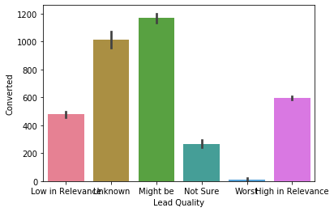

```python
# Visualisation of Lead Quality with Converted.
sns.barplot(x='Lead Quality', y='Converted', palette='husl', data=leadscr_data, estimator=np.sum)
```

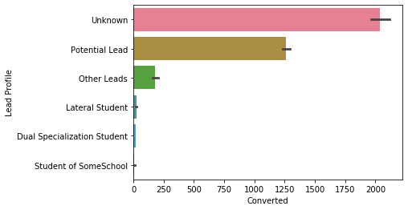

```python
# Visualization of Lead Profile against converted
sns.barplot(y='Lead Profile', x='Converted', palette='husl', data=leadscr_data, estimator=np.sum)
```

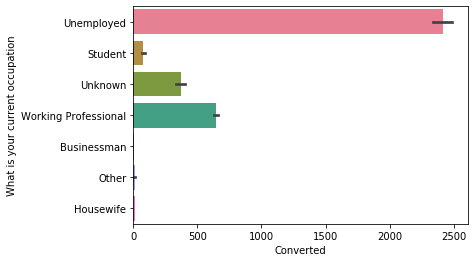

```python
# Visualization Current Occupation against Converted column
sns.barplot(y='What is your current occupation', x='Converted', palette='husl', data=leadscr_data, estimator=np.sum)
```

## Outlier Detection

```python
# Checking outliers at 25%,50%,75%,90%,95% and 99%
leadscr_data.describe(percentiles=[.25,.5,.75,.90,.95,.99])
```

|  | Do Not Email | Converted | TotalVisits | Total Time Spent on Website | Page Views Per Visit | X Education Forums | Digital Advertisement | A free copy of Mastering The Interview |
| --- | --- | --- | --- | --- | --- | --- | --- | --- |
| count | 9204.000000 | 9204.000000 | 9204.000000 | 9204.000000 | 9204.000000 | 9204.000000 | 9204.000000 | 9204.000000 |
| mean | 0.078336 | 0.383746 | 3.449587 | 489.005541 | 2.364923 | 0.000109 | 0.000435 | 0.313777 |
| std | 0.268713 | 0.486324 | 4.824662 | 547.980340 | 2.145999 | 0.010423 | 0.020844 | 0.464052 |
| min | 0.000000 | 0.000000 | 0.000000 | 0.000000 | 0.000000 | 0.000000 | 0.000000 | 0.000000 |
| 25% | 0.000000 | 0.000000 | 1.000000 | 14.000000 | 1.000000 | 0.000000 | 0.000000 | 0.000000 |
| 50% | 0.000000 | 0.000000 | 3.000000 | 250.000000 | 2.000000 | 0.000000 | 0.000000 | 0.000000 |
| 75% | 0.000000 | 1.000000 | 5.000000 | 938.000000 | 3.000000 | 0.000000 | 0.000000 | 1.000000 |
| 90% | 0.000000 | 1.000000 | 7.000000 | 1380.000000 | 5.000000 | 0.000000 | 0.000000 | 1.000000 |
| 95% | 1.000000 | 1.000000 | 10.000000 | 1562.000000 | 6.000000 | 0.000000 | 0.000000 | 1.000000 |
| 99% | 1.000000 | 1.000000 | 17.000000 | 1839.970000 | 9.000000 | 0.000000 | 0.000000 | 1.000000 |
| max | 1.000000 | 1.000000 | 251.000000 | 2272.000000 | 55.000000 | 1.000000 | 1.000000 | 1.000000 |

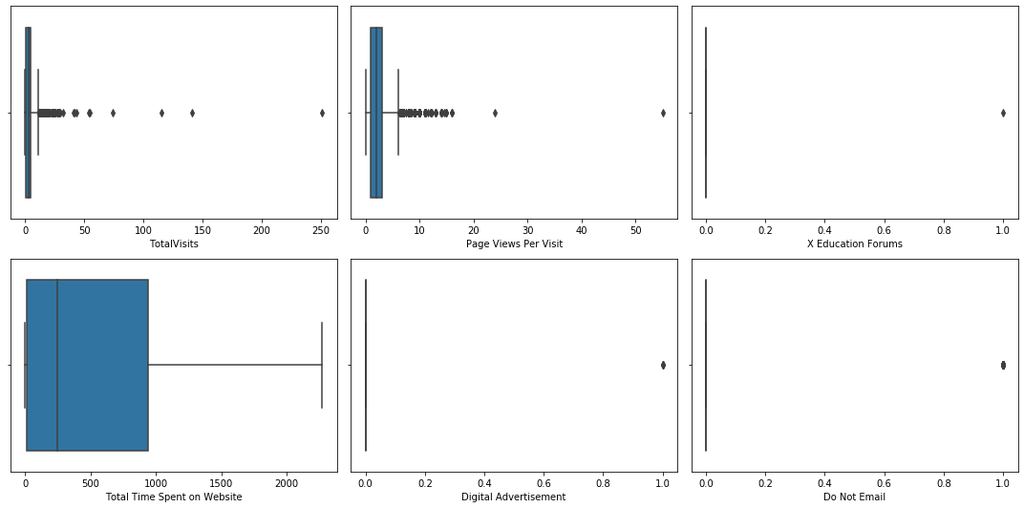

```python
fig, axs = plt.subplots(2,3, figsize = (15,7.5))
plt1 = sns.boxplot(leadscr_data['TotalVisits'], ax = axs[0,0])
plt2 = sns.boxplot(leadscr_data['Page Views Per Visit'], ax = axs[0,1])
plt3 = sns.boxplot(leadscr_data['X Education Forums'], ax = axs[0,2])
plt4 = sns.boxplot(leadscr_data['Total Time Spent on Website'], ax = axs[1,0])
plt5 = sns.boxplot(leadscr_data['Digital Advertisement'], ax = axs[1,1])
plt6 = sns.boxplot(leadscr_data['Do Not Email'], ax = axs[1,2])


plt.tight_layout()
```

```python
# Outlier analysis

Q1 = leadscr_data['TotalVisits'].quantile(0.25)
Q3 = leadscr_data['TotalVisits'].quantile(0.75)
IQR = Q3 - Q1
leadscr_data=leadscr_data.loc[(leadscr_data['TotalVisits'] >= Q1 - 1.5*IQR) & (leadscr_data['TotalVisits'] <= Q3 + 1.4*IQR)]

Q1 = leadscr_data['Page Views Per Visit'].quantile(0.25)
Q3 = leadscr_data['Page Views Per Visit'].quantile(0.75)
IQR = Q3 - Q1
leadscr_data=leadscr_data.loc[(leadscr_data['Page Views Per Visit'] >= Q1 - 1.5*IQR) & (leadscr_data['Page Views Per Visit'] <= Q3 + 1.5*IQR)]

leadscr_data.shape
```

```
(8575, 21)
```

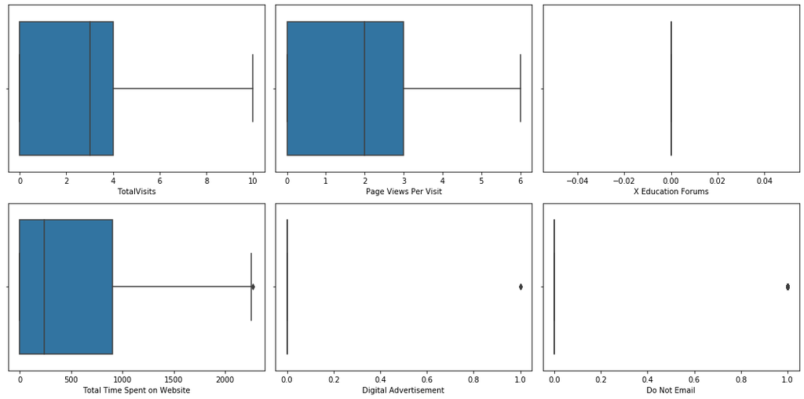

```python
fig, axs = plt.subplots(2,3, figsize = (15,7.5))
plt1 = sns.boxplot(leadscr_data['TotalVisits'], ax = axs[0,0])
#
plt2 = sns.boxplot(leadscr_data['Page Views Per Visit'], ax = axs[0,1])
plt3 = sns.boxplot(leadscr_data['X Education Forums'], ax = axs[0,2])
plt4 = sns.boxplot(leadscr_data['Total Time Spent on Website'], ax = axs[1,0])
plt5 = sns.boxplot(leadscr_data['Digital Advertisement'], ax = axs[1,1])
plt6 = sns.boxplot(leadscr_data['Do Not Email'], ax = axs[1,2])


plt.tight_layout()
```

### Normalization

3 columns are normalized they are: TotalVisits Total Time Spent on Website Page Views Per Visit

```python
# Normalising continuous features
df = leadscr_data[["TotalVisits", "Total Time Spent on Website", "Page Views Per Visit"]]
### Columns that are required to be normalized

normalized_df=(df-df.mean())/df.std()
leadscr_data = leadscr_data.drop(["TotalVisits", "Total Time Spent on Website", "Page Views Per Visit"], 1)
# dropping the columns normalized

leadscr_data = pd.concat([leadscr_data,normalized_df],axis=1)
leadscr_data.head()
```

|  | Lead Origin | Lead Source | Do Not Email | Converted | Last Activity | Country | Specialization | What is your current occupation | X Education Forums | Digital Advertisement | Tags | Lead Quality | Lead Profile | City | Asymmetrique Activity Index | Asymmetrique Profile Index | A free copy of Mastering The Interview | Last Notable Activity | TotalVisits | Total Time Spent on Website | Page Views Per Visit |
| --- | --- | --- | --- | --- | --- | --- | --- | --- | --- | --- | --- | --- | --- | --- | --- | --- | --- | --- | --- | --- | --- |
| 0 | API | Olark Chat | 0 | 0 | Page Visited on Website | India | Select | Unemployed | 0 | 0 | Interested in other courses | Low in Relevance | Unknown | Unknown | 02.Medium | 02.Medium | 0 | Modified | -1.192442 | -0.872429 | -1.265413 |
| 1 | API | Organic Search | 0 | 0 | Email Opened | India | Select | Unemployed | 0 | 0 | Ringing | Unknown | Unknown | Unknown | 02.Medium | 02.Medium | 0 | Email Opened | 0.969423 | 0.364575 | 0.262224 |
| 2 | Landing Page Submission | Direct Traffic | 0 | 1 | Email Opened | India | Business Administration | Student | 0 | 0 | Will revert after reading the email | Might be | Potential Lead | Mumbai | 02.Medium | 01.High | 1 | Email Opened | -0.327696 | 1.939277 | -0.043303 |
| 3 | Landing Page Submission | Direct Traffic | 0 | 0 | Unreachable | India | Media and Advertising | Unemployed | 0 | 0 | Ringing | Not Sure | Unknown | Mumbai | 02.Medium | 01.High | 0 | Modified | -0.760069 | -0.312657 | -0.654358 |
| 4 | Landing Page Submission | Google | 0 | 1 | Converted to Lead | India | Select | Unemployed | 0 | 0 | Will revert after reading the email | Might be | Unknown | Mumbai | 02.Medium | 01.High | 0 | Modified | -0.327696 | 1.748404 | -0.654358 |

### Data Encoding

Encoding variables having more than 2 categories

```python
# Encoding the categorical variables
dataset_LS = pd.DataFrame()
dataset_LS = leadscr_data["Lead Origin"]
dataset_LS = pd.get_dummies(dataset_LS,prefix=['Lead Origin'], drop_first=True)
leadscr_data = pd.concat([leadscr_data, dataset_LS], axis=1)



dataset_LS = pd.DataFrame()
dataset_LS = leadscr_data["Lead Source"]
dataset_LS = pd.get_dummies(dataset_LS,prefix=['Lead Source'], drop_first=True)
leadscr_data = pd.concat([leadscr_data, dataset_LS], axis=1)


dataset_LS = pd.DataFrame()
dataset_LS = leadscr_data["Last Activity"]
dataset_LS = pd.get_dummies(dataset_LS,prefix=['Last Activity'], drop_first=True)
leadscr_data = pd.concat([leadscr_data, dataset_LS], axis=1)



dataset_LS = pd.DataFrame()
dataset_LS = leadscr_data["Country"]
dataset_LS = pd.get_dummies(dataset_LS,prefix=['Country'], drop_first=True)
leadscr_data = pd.concat([leadscr_data, dataset_LS], axis=1)



dataset_LS = pd.DataFrame()
dataset_LS = leadscr_data["Specialization"]
dataset_LS = pd.get_dummies(dataset_LS,prefix=['Specialization'], drop_first=True)
leadscr_data = pd.concat([leadscr_data, dataset_LS], axis=1)




dataset_LS = pd.DataFrame()
dataset_LS = leadscr_data["What is your current occupation"]
dataset_LS = pd.get_dummies(dataset_LS,prefix=['What is your current occupation'], drop_first=True)
leadscr_data = pd.concat([leadscr_data, dataset_LS], axis=1)



dataset_LS = pd.DataFrame()
dataset_LS = leadscr_data["Tags"]
dataset_LS = pd.get_dummies(dataset_LS,prefix=['Tags'], drop_first=True)
leadscr_data = pd.concat([leadscr_data, dataset_LS], axis=1)


dataset_LS = pd.DataFrame()
dataset_LS = leadscr_data["Lead Quality"]
dataset_LS = pd.get_dummies(dataset_LS,prefix=['Lead Quality'], drop_first=True)
leadscr_data = pd.concat([leadscr_data, dataset_LS], axis=1)


dataset_LS = pd.DataFrame()
dataset_LS = leadscr_data["Lead Profile"]
pd.get_dummies(dataset_LS,prefix=['Lead Profile'], drop_first=True)
leadscr_data = pd.concat([leadscr_data, dataset_LS], axis=1)


dataset_LS = pd.DataFrame()
dataset_LS = leadscr_data["City"]
dataset_LS = pd.get_dummies(dataset_LS,prefix=['City'], drop_first=True)
leadscr_data = pd.concat([leadscr_data, dataset_LS], axis=1)



dataset_LS = pd.DataFrame()
dataset_LS = leadscr_data["Asymmetrique Activity Index"]
dataset_LS = pd.get_dummies(dataset_LS,prefix=['Asymmetrique Activity Index'], drop_first=True)
leadscr_data = pd.concat([leadscr_data, dataset_LS], axis=1)



dataset_LS = pd.DataFrame()
dataset_LS = leadscr_data["Asymmetrique Profile Index"]
dataset_LS = pd.get_dummies(dataset_LS,prefix=['Asymmetrique Profile Index'], drop_first=True)
leadscr_data = pd.concat([leadscr_data, dataset_LS], axis=1)



dataset_LS = pd.DataFrame()
dataset_LS = leadscr_data["Last Notable Activity"]
dataset_LS = pd.get_dummies(dataset_LS,prefix=['Last Notable Activity'], drop_first=True)
leadscr_data = pd.concat([leadscr_data, dataset_LS], axis=1)


leadscr_data = leadscr_data.drop(["Last Notable Activity", "Asymmetrique Profile Index", "Asymmetrique Activity Index",
                       "City", "Lead Profile", "Tags", "What is your current occupation", "Specialization",
                       "Country", "Last Activity", "Lead Origin", "Lead Source", "Lead Quality"], axis=1)


leadscr_data.head()
```

|  | Do Not Email | Converted | X Education Forums | Digital Advertisement | A free copy of Mastering The Interview | TotalVisits | Total Time Spent on Website | Page Views Per Visit | ['Lead Origin']_Landing Page Submission | ['Lead Origin']_Lead Add Form | ['Lead Origin']_Lead Import | ['Lead Source']_Direct Traffic | ['Lead Source']_Facebook | ['Lead Source']_Google | ['Lead Source']_Live Chat | ['Lead Source']_NC_EDM | ['Lead Source']_Olark Chat | ['Lead Source']_Organic Search | ['Lead Source']_Pay per Click Ads | ['Lead Source']_Press_Release | ['Lead Source']_Reference | ['Lead Source']_Referral Sites | ['Lead Source']_Social Media | ['Lead Source']_WeLearn | ['Lead Source']_Welingak Website | ['Lead Source']_bing | ['Lead Source']_blog | ['Lead Source']_google | ['Lead Source']_testone | … |
| --- | --- | --- | --- | --- | --- | --- | --- | --- | --- | --- | --- | --- | --- | --- | --- | --- | --- | --- | --- | --- | --- | --- | --- | --- | --- | --- | --- | --- | --- | --- |
| 0 | 0 | 0 | 0 | 0 | 0 | -1.192442 | -0.872429 | -1.265413 | 0 | 0 | 0 | 0 | 0 | 0 | 0 | 0 | 1 | 0 | 0 | 0 | 0 | 0 | 0 | 0 | 0 | 0 | 0 | 0 | 0 | … |
| 1 | 0 | 0 | 0 | 0 | 0 | 0.969423 | 0.364575 | 0.262224 | 0 | 0 | 0 | 0 | 0 | 0 | 0 | 0 | 0 | 1 | 0 | 0 | 0 | 0 | 0 | 0 | 0 | 0 | 0 | 0 | 0 | … |
| 2 | 0 | 1 | 0 | 0 | 1 | -0.327696 | 1.939277 | -0.043303 | 1 | 0 | 0 | 1 | 0 | 0 | 0 | 0 | 0 | 0 | 0 | 0 | 0 | 0 | 0 | 0 | 0 | 0 | 0 | 0 | 0 | … |
| 3 | 0 | 0 | 0 | 0 | 0 | -0.760069 | -0.312657 | -0.654358 | 1 | 0 | 0 | 1 | 0 | 0 | 0 | 0 | 0 | 0 | 0 | 0 | 0 | 0 | 0 | 0 | 0 | 0 | 0 | 0 | 0 | … |
| 4 | 0 | 1 | 0 | 0 | 0 | -0.327696 | 1.748404 | -0.654358 | 1 | 0 | 0 | 0 | 0 | 1 | 0 | 0 | 0 | 0 | 0 | 0 | 0 | 0 | 0 | 0 | 0 | 0 | 0 | 0 | 0 | … |

### Splitting Data into Training and Test Sets

```python
from sklearn.model_selection import train_test_split

# Putting feature variable to X
X = leadscr_data.drop(['Converted'],axis=1) # dropping ID column and predictpr column

# Putting response variable to y
y = leadscr_data['Converted'] # The predictor column

y.head()
```

```
0    0
1    0
2    1
3    0
4    1
Name: Converted, dtype: int64
```

```python
# Splitting the data into train and test
X_train, X_test, y_train, y_test = train_test_split(X,y, train_size=0.7,test_size=0.3,random_state=100)
```

### Running First Training Model

```python
import statsmodels.api as sm

# Logistic regression model
logm1 = sm.GLM(y_train,(sm.add_constant(X_train.astype(float))), family = sm.families.Binomial())
logm1.fit().summary()
```

Generalized Linear Model Regression Results

| Dep. Variable: | Converted | No. Observations: | 6002 |
| --- | --- | --- | --- |
| Model: | GLM | Df Residuals: | 5879 |
| Model Family: | Binomial | Df Model: | 122 |
| Link Function: | logit | Scale: | 1.0000 |
| Method: | IRLS | Log-Likelihood: | nan |
| Date: | Mon, 02 Mar 2020 | Deviance: | nan |
| Time: | 23:40:15 | Pearson chi2: | 2.03e+18 |
| No. Iterations: | 100 |  |  |
| Covariance Type: | nonrobust |  |  |

|  | coef | std err | z | P>\|z\| | [0.025 | 0.975] |
| --- | --- | --- | --- | --- | --- | --- |
| const | -6.775e+15 | 1.15e+08 | -5.89e+07 | 0.000 | -6.78e+15 | -6.78e+15 |
| Do Not Email | -2.462e+14 | 4.66e+06 | -5.28e+07 | 0.000 | -2.46e+14 | -2.46e+14 |
| X Education Forums | -1236.6852 | 2.96e-06 | -4.18e+08 | 0.000 | -1236.685 | -1236.685 |
| Digital Advertisement | -3.078e+14 | 4.85e+07 | -6.34e+06 | 0.000 | -3.08e+14 | -3.08e+14 |
| A free copy of Mastering The Interview | -4.09e+13 | 2.93e+06 | -1.4e+07 | 0.000 | -4.09e+13 | -4.09e+13 |
| TotalVisits | 4.876e+13 | 1.51e+06 | 3.22e+07 | 0.000 | 4.88e+13 | 4.88e+13 |
| Total Time Spent on Website | 1.051e+14 | 1.07e+06 | 9.84e+07 | 0.000 | 1.05e+14 | 1.05e+14 |
| Page Views Per Visit | -8.014e+13 | 1.64e+06 | -4.9e+07 | 0.000 | -8.01e+13 | -8.01e+13 |
| ['Lead Origin']_Landing Page Submission | -5.634e+13 | 4.22e+06 | -1.34e+07 | 0.000 | -5.63e+13 | -5.63e+13 |
| ['Lead Origin']_Lead Add Form | 8.515e+15 | 6.77e+07 | 1.26e+08 | 0.000 | 8.52e+15 | 8.52e+15 |
| ['Lead Origin']_Lead Import | 4.041e+15 | 4.01e+07 | 1.01e+08 | 0.000 | 4.04e+15 | 4.04e+15 |
| ['Lead Source']_Direct Traffic | 8.342e+15 | 7.95e+07 | 1.05e+08 | 0.000 | 8.34e+15 | 8.34e+15 |
| ['Lead Source']_Facebook | 4.041e+15 | 4.01e+07 | 1.01e+08 | 0.000 | 4.04e+15 | 4.04e+15 |
| ['Lead Source']_Google | 8.347e+15 | 7.95e+07 | 1.05e+08 | 0.000 | 8.35e+15 | 8.35e+15 |
| ['Lead Source']_Live Chat | 1.823e+16 | 6.31e+07 | 2.89e+08 | 0.000 | 1.82e+16 | 1.82e+16 |
| ['Lead Source']_NC_EDM | 1.109e+16 | 1.04e+08 | 1.06e+08 | 0.000 | 1.11e+16 | 1.11e+16 |
| ['Lead Source']_Olark Chat | 8.411e+15 | 7.94e+07 | 1.06e+08 | 0.000 | 8.41e+15 | 8.41e+15 |
| ['Lead Source']_Organic Search | 8.264e+15 | 7.96e+07 | 1.04e+08 | 0.000 | 8.26e+15 | 8.26e+15 |
| ['Lead Source']_Pay per Click Ads | 5.484e+15 | 1.04e+08 | 5.26e+07 | 0.000 | 5.48e+15 | 5.48e+15 |
| ['Lead Source']_Press_Release | 205.2857 | 1.19e-06 | 1.72e+08 | 0.000 | 205.286 | 205.286 |
| ['Lead Source']_Reference | -1.649e+14 | 4.15e+07 | -3.98e+06 | 0.000 | -1.65e+14 | -1.65e+14 |
| ['Lead Source']_Referral Sites | 8.167e+15 | 7.99e+07 | 1.02e+08 | 0.000 | 8.17e+15 | 8.17e+15 |
| ['Lead Source']_Social Media | 5.794e+15 | 1.06e+08 | 5.46e+07 | 0.000 | 5.79e+15 | 5.79e+15 |
| ['Lead Source']_WeLearn | 66.2297 | 8.22e-07 | 8.06e+07 | 0.000 | 66.230 | 66.230 |
| ['Lead Source']_Welingak Website | 6.022e+14 | 4.2e+07 | 1.43e+07 | 0.000 | 6.02e+14 | 6.02e+14 |
| ['Lead Source']_bing | -1.195e+16 | 9.28e+07 | -1.29e+08 | 0.000 | -1.2e+16 | -1.2e+16 |
| ['Lead Source']_blog | -5.785e+15 | 1.04e+08 | -5.54e+07 | 0.000 | -5.78e+15 | -5.78e+15 |
| ['Lead Source']_google | -1.329e+16 | 9.31e+07 | -1.43e+08 | 0.000 | -1.33e+16 | -1.33e+16 |
| ['Lead Source']_testone | -1.29e+15 | 1.04e+08 | -1.24e+07 | 0.000 | -1.29e+15 | -1.29e+15 |
| ['Lead Source']_welearnblog_Home | 7.064e+15 | 1.04e+08 | 6.78e+07 | 0.000 | 7.06e+15 | 7.06e+15 |

[output cut: 102 more lines]

### Correlation Matrix

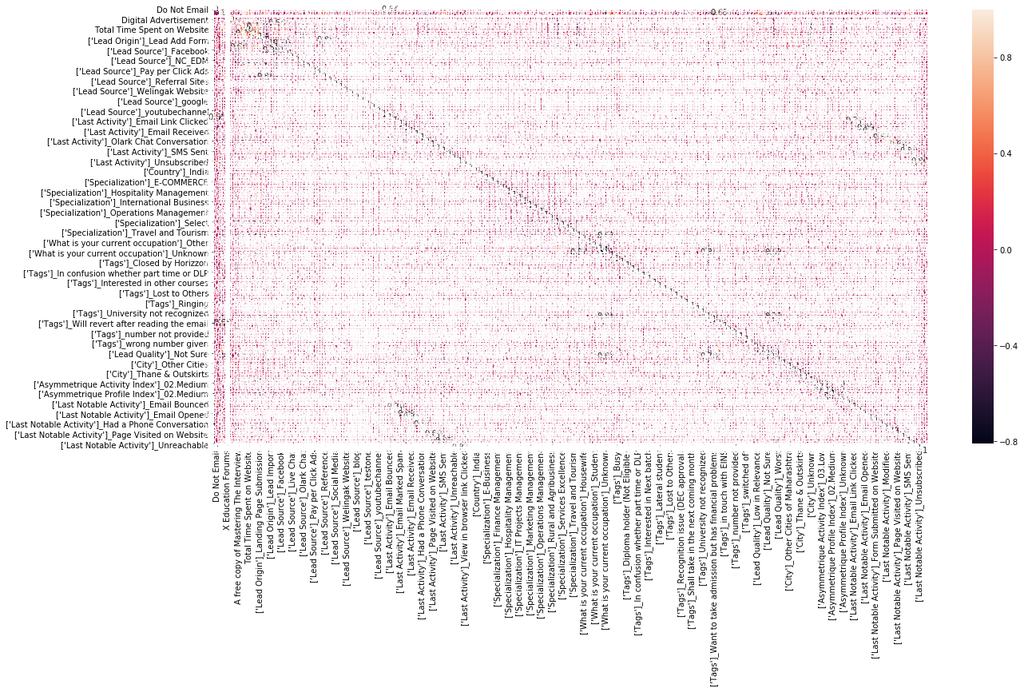

```python
# Importing matplotlib and seaborn
import matplotlib.pyplot as plt
import seaborn as sns
%matplotlib inline


# Let's see the correlation matrix
plt.figure(figsize = (20,10))        # Size of the figure
sns.heatmap(leadscr_data.corr(),annot = True)
```